# Tugas 4 MPDW

Dinda Khamila Nurfatimah

2023-09-21

## White Noise

*White noise* dibangkitkan dari suatu peubah acak, umumnya peubah acak normal.

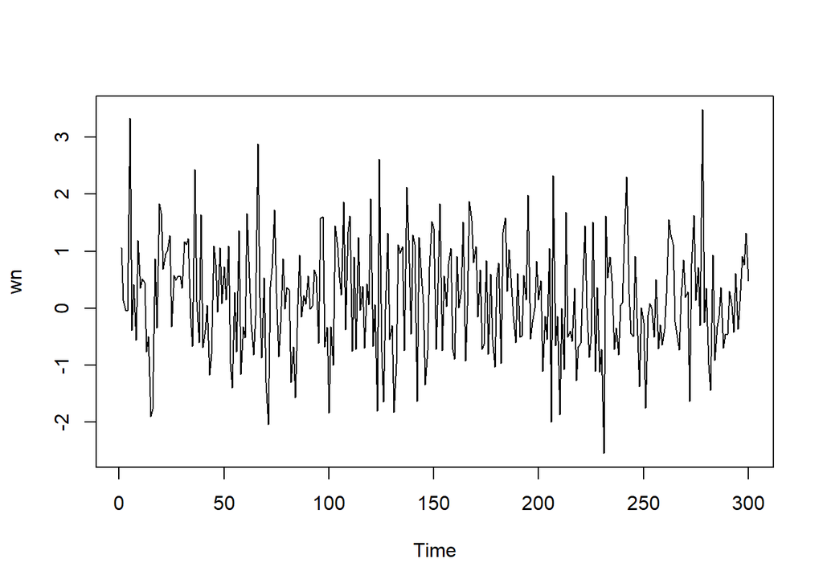

```r
set.seed(035)
wn <- rnorm(300)
ts.plot(wn)
```

Dapat terlihat bahwa *white noise* tidak memiliki autokorelasi dari ACF. Perhatikan bahwa lag ke-0 adalah korelasi observasi ke-t dengan dirinya sendiri. Nilai korelasi tersebut pasti 1. Sebagai alternatif, lag pertama di plot ACF dapat ditetapkan sebagai 1 (alih-alih 0) dengan menambahkan argumen `xlim(1, lag akhir)`. Plot tersebut dapat disandingkan bersamaan dengan membuat matriks $1 \times 2$ dengan `par(mfrow = c(1,2))`.

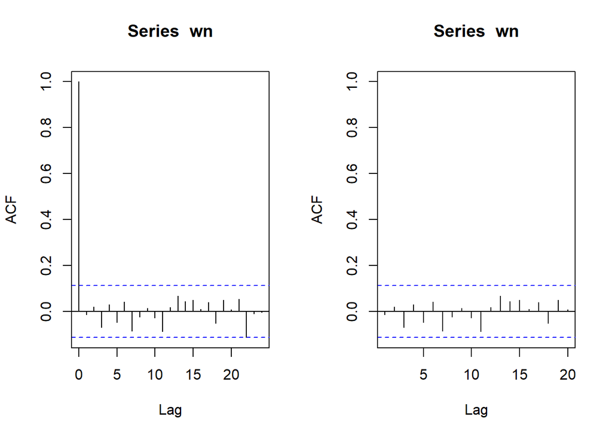

```r
par(mfrow = c(1, 2))
acf(wn)
acf(wn, xlim = c(1, 20))
```

## Proses MA

Proses MA dapat dituliskan sebagai berikut:

$$y_{t} = c + e_t + \theta_{1}e_{t-1} + \theta_{2}e_{t-2} + \dots +
\theta_{q}e_{t-q} = c+{e_t+\sum_{i=1}^p \theta_ie_{t-i}}$$
Terlihat bahwa $e_t$, atau *white noise*, berperan penting dalam pembangkitan proses MA.

## Pembangkitan Proses MA(2)

Akan dicoba membangkitkan proses MA, yaitu MA(2) dengan $\theta1 = 0.4$ dan $\theta2 = 0.6$ sebanyak 300 observasi dan $c=0$. Karena diperlukan satu nilai awal untuk $e_{t-1}$ dan $e_{t-2}$, masukkan nilai pertama white noise sebagai nilai awal tersebut.

```r
set.seed(035)
ma <- wn[c(1,2)]
```

Nilai-nilai selanjutnya dapat dicari melalui *loop*. Bentuk loop dapat dilihat dari rumus MA(2) yang hendak dibangkitkan:

```r
for(i in 3:300){
   ma[i] <- wn[i] + 0.4 * wn[i - 1]+ 0.6 * wn[i - 2]
}
ma
```

```
##   [1]  1.065125327  0.132881183  0.658183657  0.021134760  3.299420916
##   [6]  0.915231810  2.256101722 -0.633709544  1.212692091  0.488247563
##  [11]  1.365917354  0.859402939 -0.283312528 -0.541257282 -2.570059470
##  [16] -2.842772162 -0.992370374 -1.067240744  2.218516529  2.200945279
##  [21]  2.456432824  2.234504393  1.795219724  2.251167470  0.790990469
##  [26]  1.215940621  0.526099293  1.094760371  1.080962605  0.908300966
##  [31]  1.652803499  1.790913751  2.372726341  0.977329459 -0.011604417
##  [36]  2.056545611  0.680957663  0.901810835  1.465150702 -0.401660786
##  [41]  0.319160465 -0.522727520 -1.385340145 -1.252614832  0.060156387
##  [46]  0.716966475  0.894508358  1.499279489  0.469600491  1.402106532
##  [51]  0.485686038  1.584133220 -0.450447425 -1.134048977 -0.870574767
##  [56] -1.499551006  1.219248831 -1.084224277  0.025365132 -1.345499887
##  [61]  1.256230369  0.885180465  0.928511990 -0.615893983 -0.629149599
##  [66]  2.333284252  1.260046662  0.928009646  0.300440456 -1.609279361
##  [71] -2.243711296 -1.228093288 -0.384008230  2.222052781  1.366946810
```

[output cut: 45 more lines]

Selain menggunakan cara di atas, pembangkitan proses MA(2) dapat dilakukan dengan fungsi `arima.sim()` sebagai berikut.

```r
ma2 <- arima.sim(list(order=c(0,0,2), ma=c(0.4,0.6)), n=300)
ma2
```

```
## Time Series:
## Start = 1
## End = 300
## Frequency = 1
##   [1]  0.658183657  0.021134760  3.299420916  0.915231810  2.256101722
##   [6] -0.633709544  1.212692091  0.488247563  1.365917354  0.859402939
##  [11] -0.283312528 -0.541257282 -2.570059470 -2.842772162 -0.992370374
##  [16] -1.067240744  2.218516529  2.200945279  2.456432824  2.234504393
##  [21]  1.795219724  2.251167470  0.790990469  1.215940621  0.526099293
##  [26]  1.094760371  1.080962605  0.908300966  1.652803499  1.790913751
##  [31]  2.372726341  0.977329459 -0.011604417  2.056545611  0.680957663
##  [36]  0.901810835  1.465150702 -0.401660786  0.319160465 -0.522727520
##  [41] -1.385340145 -1.252614832  0.060156387  0.716966475  0.894508358
##  [46]  1.499279489  0.469600491  1.402106532  0.485686038  1.584133220
##  [51] -0.450447425 -1.134048977 -0.870574767 -1.499551006  1.219248831
```

[output cut: 49 more lines]

## Karakteristik MA(2)

### Plot Time Series

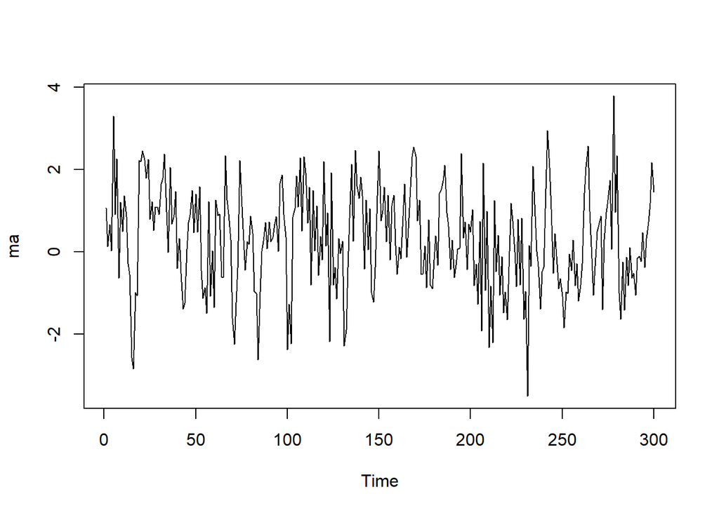

```r
ts.plot(ma)
```

Berdasarkan plot time series, terlihat bahwa data MA(2) yang dibangkitkan stasioner dalam rataan

### Plot ACF

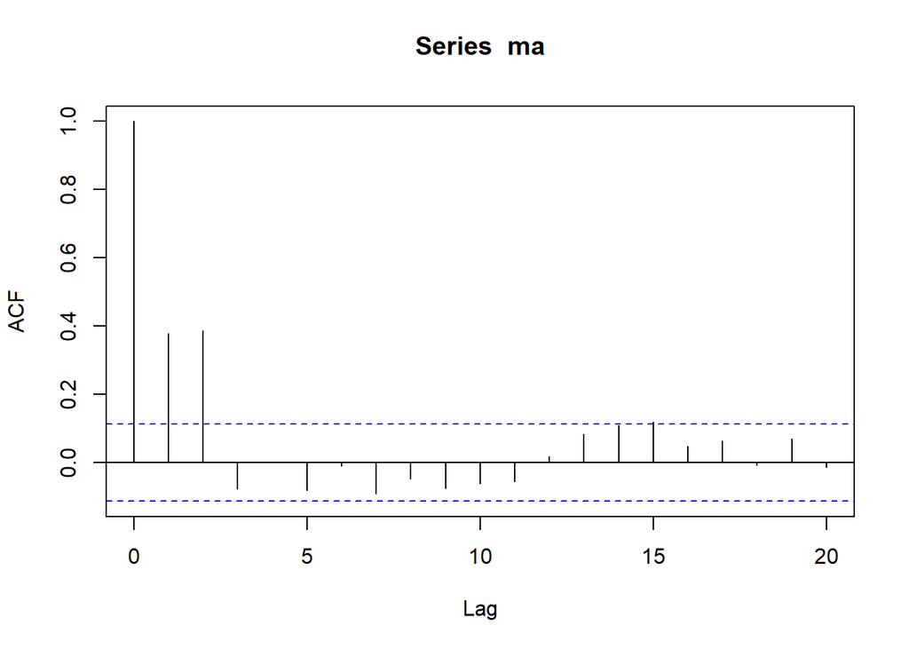

```r
acf(ma,lag.max = 20)
```

Berdasarkan plot AFC tersebut, terlihat bahwa plot ACF *cuts off* di lag kedua

### Plot PACF

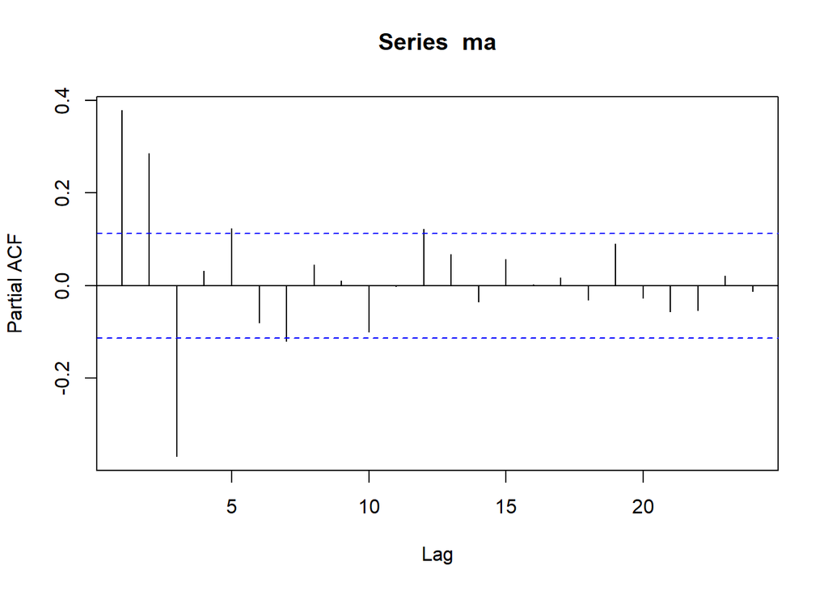

```r
pacf(ma)
```

Berdasarkan plot PACF tersebut, terlihat bahwa plot PACF cenderung *tails off* dan membentuk gelombang sinus

### Plot EACF

```r
TSA::eacf(ma)
```

```
## AR/MA
##   0 1 2 3 4 5 6 7 8 9 10 11 12 13
## 0 x x o o o o o o o o o  o  o  o
## 1 x x o o o o o o o o o  o  o  o
## 2 x x o x o o o o o o o  o  o  o
## 3 o x x x o o o o o o o  o  o  o
## 4 x x o x o o o o o o o  o  o  o
## 5 x x x x o x o o o o o  o  o  o
## 6 x x x x o o o o o o o  o  o  o
## 7 x x x x o o o o o o o  o  o  o
```

Berdasarkan pola segitiga nol pada plot EACF, terlihat bahwa segitiga nol berada pada ordo AR(0) dan ordo MA(2)

### Scatterplot Antar Lag

#### Korelasi antara $Y_t$ dengan $Y_{t-1}$

```r
#Yt
yt_ma <- ma[-1]
yt_ma
```

```
##   [1]  0.132881183  0.658183657  0.021134760  3.299420916  0.915231810
##   [6]  2.256101722 -0.633709544  1.212692091  0.488247563  1.365917354
##  [11]  0.859402939 -0.283312528 -0.541257282 -2.570059470 -2.842772162
##  [16] -0.992370374 -1.067240744  2.218516529  2.200945279  2.456432824
##  [21]  2.234504393  1.795219724  2.251167470  0.790990469  1.215940621
##  [26]  0.526099293  1.094760371  1.080962605  0.908300966  1.652803499
##  [31]  1.790913751  2.372726341  0.977329459 -0.011604417  2.056545611
##  [36]  0.680957663  0.901810835  1.465150702 -0.401660786  0.319160465
##  [41] -0.522727520 -1.385340145 -1.252614832  0.060156387  0.716966475
##  [46]  0.894508358  1.499279489  0.469600491  1.402106532  0.485686038
##  [51]  1.584133220 -0.450447425 -1.134048977 -0.870574767 -1.499551006
##  [56]  1.219248831 -1.084224277  0.025365132 -1.345499887  1.256230369
##  [61]  0.885180465  0.928511990 -0.615893983 -0.629149599  2.333284252
##  [66]  1.260046662  0.928009646  0.300440456 -1.609279361 -2.243711296
##  [71] -1.228093288 -0.384008230  2.222052781  1.366946810  0.286202500
```

[output cut: 45 more lines]

```r
#Yt-1
yt_1_ma <- ma[-300]
yt_1_ma
```

```
##   [1]  1.065125327  0.132881183  0.658183657  0.021134760  3.299420916
##   [6]  0.915231810  2.256101722 -0.633709544  1.212692091  0.488247563
##  [11]  1.365917354  0.859402939 -0.283312528 -0.541257282 -2.570059470
##  [16] -2.842772162 -0.992370374 -1.067240744  2.218516529  2.200945279
##  [21]  2.456432824  2.234504393  1.795219724  2.251167470  0.790990469
##  [26]  1.215940621  0.526099293  1.094760371  1.080962605  0.908300966
##  [31]  1.652803499  1.790913751  2.372726341  0.977329459 -0.011604417
##  [36]  2.056545611  0.680957663  0.901810835  1.465150702 -0.401660786
##  [41]  0.319160465 -0.522727520 -1.385340145 -1.252614832  0.060156387
##  [46]  0.716966475  0.894508358  1.499279489  0.469600491  1.402106532
##  [51]  0.485686038  1.584133220 -0.450447425 -1.134048977 -0.870574767
##  [56] -1.499551006  1.219248831 -1.084224277  0.025365132 -1.345499887
##  [61]  1.256230369  0.885180465  0.928511990 -0.615893983 -0.629149599
##  [66]  2.333284252  1.260046662  0.928009646  0.300440456 -1.609279361
##  [71] -2.243711296 -1.228093288 -0.384008230  2.222052781  1.366946810
```

[output cut: 45 more lines]

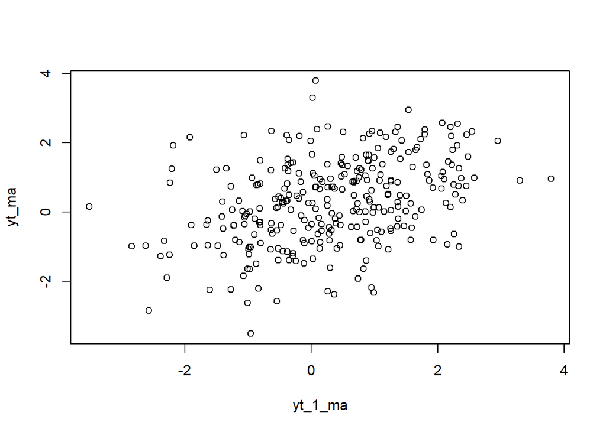

```r
plot(y=yt_ma,x=yt_1_ma)
```

Berdasarkan scatterplot tersebut, terlihat bahwa terdapat hubungan positif antara $Y_t$ dengan $Y_{t-1}$. Hal ini sesuai dengan teori yang ada

```r
cor(yt_ma,yt_1_ma)
```

```
## [1] 0.3786993
```

Korelasi antara $Y_t$ dengan $Y_{t-1}$ dari hasil simulasi mendekati perhitungan teoritis yaitu

$$\rho_1=\frac{\theta_1+\theta_1\theta_2}{1+(\theta_1)^2+(\theta_2)^2}=\frac{(0.4)+(0.4*0.6)}{1+(0.4)^2+(0.6)^2}=0.42$$

#### Korelasi antara $Y_t$ dengan $Y_{t-2}$

```r
#Yt
yt_ma2 <- ma[-c(1,2)]
yt_ma2
```

```
##   [1]  0.658183657  0.021134760  3.299420916  0.915231810  2.256101722
##   [6] -0.633709544  1.212692091  0.488247563  1.365917354  0.859402939
##  [11] -0.283312528 -0.541257282 -2.570059470 -2.842772162 -0.992370374
##  [16] -1.067240744  2.218516529  2.200945279  2.456432824  2.234504393
##  [21]  1.795219724  2.251167470  0.790990469  1.215940621  0.526099293
##  [26]  1.094760371  1.080962605  0.908300966  1.652803499  1.790913751
##  [31]  2.372726341  0.977329459 -0.011604417  2.056545611  0.680957663
##  [36]  0.901810835  1.465150702 -0.401660786  0.319160465 -0.522727520
##  [41] -1.385340145 -1.252614832  0.060156387  0.716966475  0.894508358
##  [46]  1.499279489  0.469600491  1.402106532  0.485686038  1.584133220
##  [51] -0.450447425 -1.134048977 -0.870574767 -1.499551006  1.219248831
##  [56] -1.084224277  0.025365132 -1.345499887  1.256230369  0.885180465
##  [61]  0.928511990 -0.615893983 -0.629149599  2.333284252  1.260046662
##  [66]  0.928009646  0.300440456 -1.609279361 -2.243711296 -1.228093288
##  [71] -0.384008230  2.222052781  1.366946810  0.286202500 -0.437222316
```

[output cut: 45 more lines]

```r
#Yt-2
yt_2_ma <- ma[-c(299,300)]
yt_2_ma
```

```
##   [1]  1.065125327  0.132881183  0.658183657  0.021134760  3.299420916
##   [6]  0.915231810  2.256101722 -0.633709544  1.212692091  0.488247563
##  [11]  1.365917354  0.859402939 -0.283312528 -0.541257282 -2.570059470
##  [16] -2.842772162 -0.992370374 -1.067240744  2.218516529  2.200945279
##  [21]  2.456432824  2.234504393  1.795219724  2.251167470  0.790990469
##  [26]  1.215940621  0.526099293  1.094760371  1.080962605  0.908300966
##  [31]  1.652803499  1.790913751  2.372726341  0.977329459 -0.011604417
##  [36]  2.056545611  0.680957663  0.901810835  1.465150702 -0.401660786
##  [41]  0.319160465 -0.522727520 -1.385340145 -1.252614832  0.060156387
##  [46]  0.716966475  0.894508358  1.499279489  0.469600491  1.402106532
##  [51]  0.485686038  1.584133220 -0.450447425 -1.134048977 -0.870574767
##  [56] -1.499551006  1.219248831 -1.084224277  0.025365132 -1.345499887
##  [61]  1.256230369  0.885180465  0.928511990 -0.615893983 -0.629149599
##  [66]  2.333284252  1.260046662  0.928009646  0.300440456 -1.609279361
##  [71] -2.243711296 -1.228093288 -0.384008230  2.222052781  1.366946810
```

[output cut: 45 more lines]

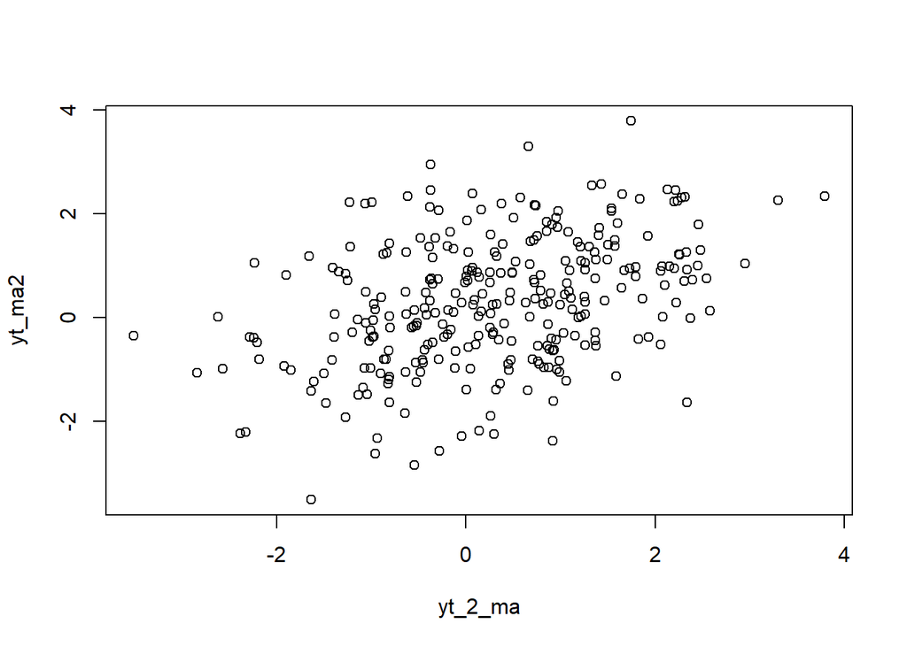

```r
plot(y=yt_ma2,x=yt_2_ma)
```

Berdasarkan scatterplot tersebut, terlihat bahwa terdapat hubungan positif antara $Y_t$ dengan $Y_{t-2}$. Hal ini sesuai dengan teori yang ada

```r
cor(yt_ma2,yt_2_ma)
```

```
## [1] 0.3897844
```

#### Korelasi antara $Y_t$ dengan $Y_{t-3}$

```r
#Yt
yt_ma3 <- ma[-c(1,2,3)]
yt_ma3
```

```
##   [1]  0.021134760  3.299420916  0.915231810  2.256101722 -0.633709544
##   [6]  1.212692091  0.488247563  1.365917354  0.859402939 -0.283312528
##  [11] -0.541257282 -2.570059470 -2.842772162 -0.992370374 -1.067240744
##  [16]  2.218516529  2.200945279  2.456432824  2.234504393  1.795219724
##  [21]  2.251167470  0.790990469  1.215940621  0.526099293  1.094760371
##  [26]  1.080962605  0.908300966  1.652803499  1.790913751  2.372726341
##  [31]  0.977329459 -0.011604417  2.056545611  0.680957663  0.901810835
##  [36]  1.465150702 -0.401660786  0.319160465 -0.522727520 -1.385340145
##  [41] -1.252614832  0.060156387  0.716966475  0.894508358  1.499279489
##  [46]  0.469600491  1.402106532  0.485686038  1.584133220 -0.450447425
##  [51] -1.134048977 -0.870574767 -1.499551006  1.219248831 -1.084224277
##  [56]  0.025365132 -1.345499887  1.256230369  0.885180465  0.928511990
##  [61] -0.615893983 -0.629149599  2.333284252  1.260046662  0.928009646
##  [66]  0.300440456 -1.609279361 -2.243711296 -1.228093288 -0.384008230
##  [71]  2.222052781  1.366946810  0.286202500 -0.437222316  0.251184461
```

[output cut: 45 more lines]

```r
#Yt-3
yt_3_ma <- ma[-c(298,299,300)]
yt_3_ma
```

```
##   [1]  1.065125327  0.132881183  0.658183657  0.021134760  3.299420916
##   [6]  0.915231810  2.256101722 -0.633709544  1.212692091  0.488247563
##  [11]  1.365917354  0.859402939 -0.283312528 -0.541257282 -2.570059470
##  [16] -2.842772162 -0.992370374 -1.067240744  2.218516529  2.200945279
##  [21]  2.456432824  2.234504393  1.795219724  2.251167470  0.790990469
##  [26]  1.215940621  0.526099293  1.094760371  1.080962605  0.908300966
##  [31]  1.652803499  1.790913751  2.372726341  0.977329459 -0.011604417
##  [36]  2.056545611  0.680957663  0.901810835  1.465150702 -0.401660786
##  [41]  0.319160465 -0.522727520 -1.385340145 -1.252614832  0.060156387
##  [46]  0.716966475  0.894508358  1.499279489  0.469600491  1.402106532
##  [51]  0.485686038  1.584133220 -0.450447425 -1.134048977 -0.870574767
##  [56] -1.499551006  1.219248831 -1.084224277  0.025365132 -1.345499887
##  [61]  1.256230369  0.885180465  0.928511990 -0.615893983 -0.629149599
##  [66]  2.333284252  1.260046662  0.928009646  0.300440456 -1.609279361
##  [71] -2.243711296 -1.228093288 -0.384008230  2.222052781  1.366946810
```

[output cut: 45 more lines]

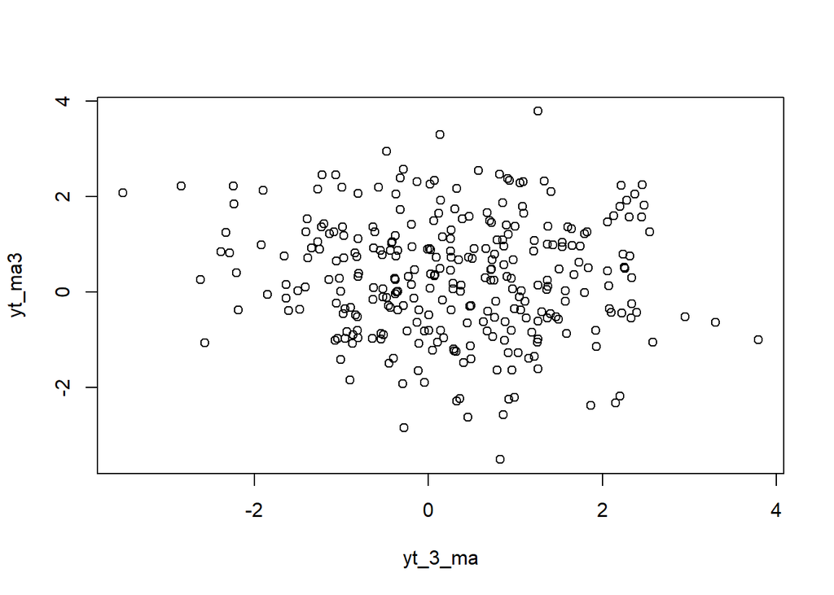

```r
plot(y=yt_ma3,x=yt_3_ma)
```

Berdasarkan scatterplot tersebut, terlihat bahwa cenderung tidak terdapat hubungan antara $Y_t$ dengan $Y_{t-3}$.

```r
cor(yt_ma3,yt_3_ma)
```

```
## [1] -0.07842954
```

Korelasi antara $Y_t$ dengan $Y_{t-3}$ hasil simulasi mendekati teori yang ada yaitu 0.

## Proses AR

Proses AR dapat dituliskan sebagai berikut:

$$y_{t} = c + e_t + \phi_{1}Y_{t-1} +
\phi_{2}Y_{t-2} + \dots + \phi_{q}Y_{t-q} = c+{e_t+\sum_{i=1}^p
\phi_iY_{t-i}}$$
Terlihat bahwa $Y_t$ berperan penting dalam pembangkitan proses AR.

## Pembangkitan Proses AR

Akan dicoba membangkitkan proses AR, yaitu AR(2) dengan $\phi1 = 0.5$ dan $\phi2 =0.2$ sebanyak 300 observasi dan $c=0$.

```r
set.seed(035)
```

Nilai-nilai selanjutnya dapat dicari melalui *loop*. Bentuk loop dapat dilihat dari rumus AR(2) yang hendak dibangkitkan:

$$Y_t = e_t+0.5Y_{t-1}+0.2Y_{t-2}$$

```r
n<-length(wn)
n
```

```
## [1] 300
```

```r
ar <- c(1:n) #bangkitkan data ar 1-300
for (i in 3:n) {ar[i]<-wn[i]+0.5*ar[i-1]+0.2*ar[i-2]} #looping dari 3-300
ar
```

```
##   [1]  1.000000000  2.000000000  1.165955987  0.938001648  4.040029883
##   [6]  1.814697744  2.125920865  0.863714547  2.048268102  1.545945122
##  [11]  1.694180277  1.601619567  0.371264692  0.004847193 -1.831910620
##  [16] -2.693657731 -0.848960327 -1.308949603  1.013994421  1.918290789
##  [21]  1.846186931  2.263708856  2.502983054  2.980469932  1.670192649
##  [26]  2.009644523  1.825961756  1.867757240  1.866634014  1.656435730
##  [31]  2.373983431  2.630476742  3.014418988  1.853562001  0.855327159
##  [36]  3.232502351  1.899226305  0.992684756  2.515564069  0.760964948
##  [41]  0.497271510  0.449843159 -0.848775762 -1.147182073  0.345806314
##  [46]  0.712429910  0.358807807  1.386418838  0.848700937  1.431531414
##  [51]  1.028995087  1.889603063  0.178539914 -0.931313695 -0.157885545
##  [56] -1.034479287  0.814903596 -0.967592210 -0.646423203 -1.031097913
##  [61]  1.012508610  0.830899026  0.339712179 -0.487081048 -0.308557477
##  [66]  2.628643225  1.440297143  0.370609149  1.011299471 -0.719521142
##  [71] -2.204256171 -0.875847780 -0.182803871  1.454982068  0.951672894
```

[output cut: 45 more lines]

Selain menggunakan cara di atas, pembangkitan proses AR dapat dilakukan dengan fungsi `arima.sim()` sebagai berikut.

```r
ar2 <- arima.sim(list(order=c(2,0,0), ar=c(0.5,0.2)), n=300)
ar2
```

```
## Time Series:
## Start = 1
## End = 300
## Frequency = 1
##   [1]  2.00818916  1.82485226  1.86691142  1.86598921  1.65594416  2.37360869
##   [7]  2.63019106  3.01420120  1.85339597  0.85520058  3.23240586  1.89915274
##  [13]  0.99262868  2.51552132  0.76093236  0.49724666  0.44982422 -0.84879020
##  [19] -1.14719308  0.34579792  0.71242351  0.35880293  1.38641512  0.84869810
##  [25]  1.43152925  1.02899344  1.88960181  0.17853896 -0.93131443 -0.15788610
##  [31] -1.03447971  0.81490327 -0.96759246 -0.64642339 -1.03109806  1.01250850
##  [37]  0.83089894  0.33971212 -0.48708110 -0.30855751  2.62864320  1.44029712
##  [43]  0.37060913  1.01129946 -0.71952115 -2.20425618 -0.87584779 -0.18280388
##  [49]  1.45498206  0.95167289 -0.08419383 -0.10501956  0.79375482  0.35967369
##  [55]  0.70256872  0.73871486 -0.79164006 -0.92445962 -2.18882978 -1.21766459
##  [61] -0.11346239 -0.44861074 -0.02640987 -0.02956201  0.54751598  0.24924632
```

[output cut: 39 more lines]

## Karakteristik AR(2)

### Plot Time Series

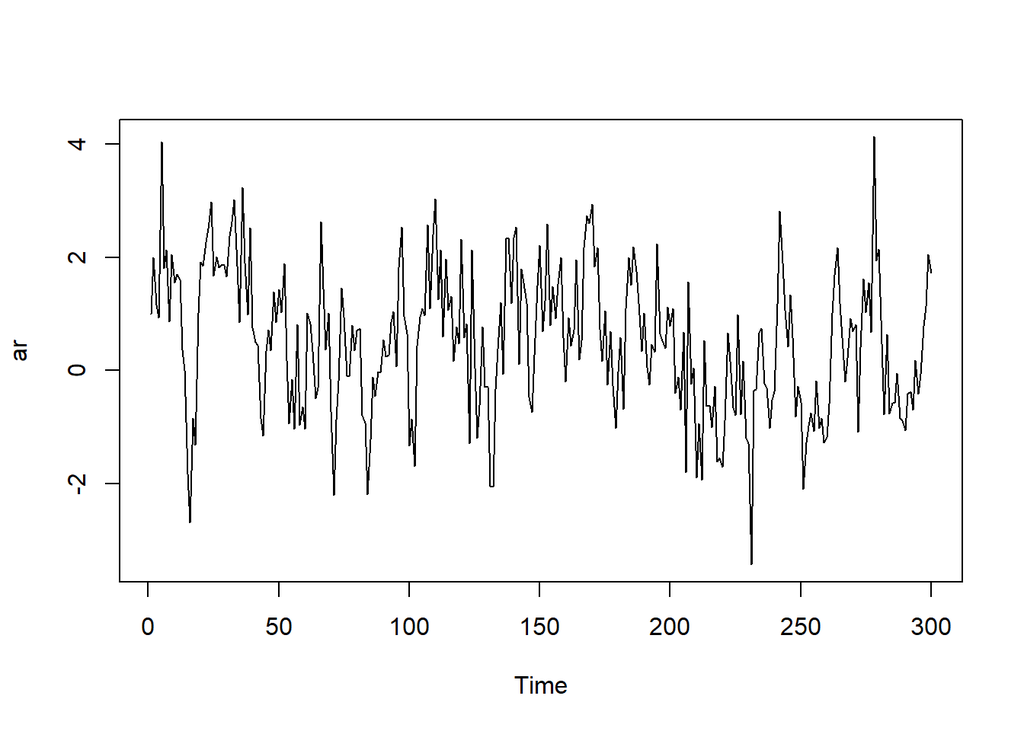

```r
ts.plot(ar)
```

Berdasarkan plot time series tersebut terlihat bahwa data cenderung stasioner pada rataan

### Plot ACF

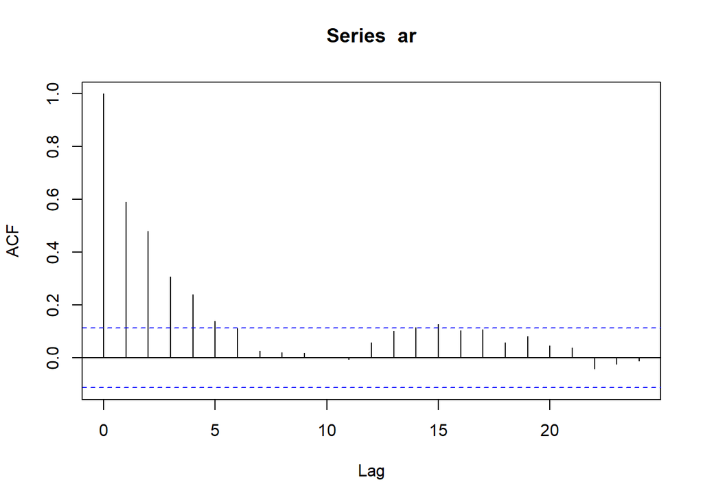

```r
acf(ar)
```

Berdasarkan plot ACF tersebut terlihat bahwa plot ACF cenderung *tails off* dan cenderung membentuk pola grafik sinus

### Plot PACF

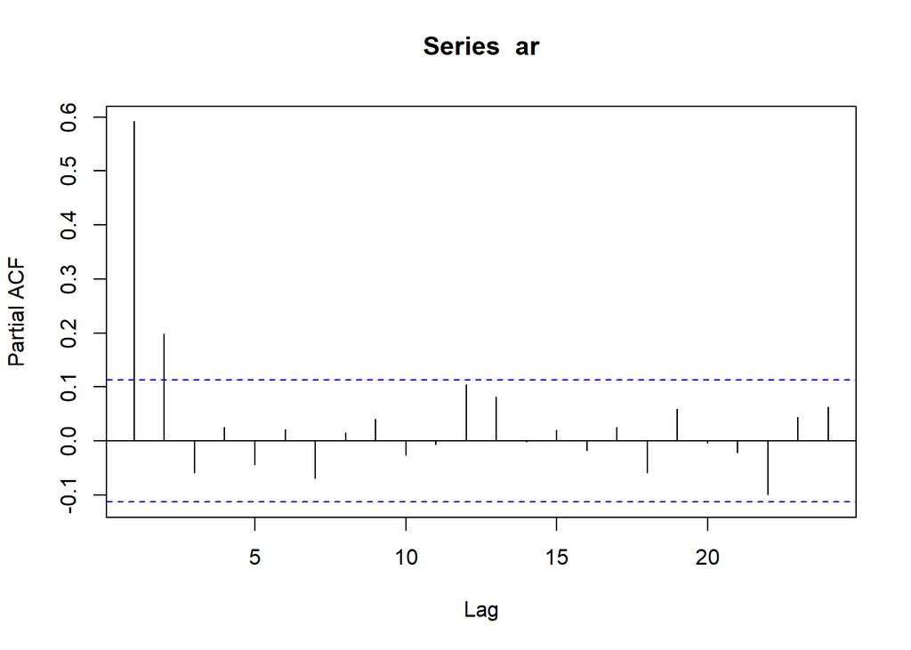

```r
pacf(ar)
```

Berdasarkan plot PACF tersebut, terlihat bahwa plot PACF *cuts off* pada lag kedua, sejalan dengan teori yang ada

### Plot EACF

```r
TSA::eacf(ar)
```

```
## AR/MA
##   0 1 2 3 4 5 6 7 8 9 10 11 12 13
## 0 x x x x x o o o o o o  o  o  o
## 1 x x o o o o o o o o o  o  o  o
## 2 x o o o o o o o o o o  o  o  o
## 3 x o o o o o o o o o o  o  o  o
## 4 x x o o o o o o o o o  o  o  o
## 5 x x o o o o o o o o o  o  o  o
## 6 x x o x x o o o o o o  o  o  o
## 7 x x o o x o o o o o o  o  o  o
```

Berdasarkan pola segitiga nol pada plot EACF, terlihat bahwa segitiga nol berada pada ordo AR(2) dan ordo MA(1)

### Scatterplot Antar Lag

#### Korelasi antara $Y_t$ dengan $Y_{t-1}$

```r
#Yt
yt_ar <- ar[-1]
yt_ar
```

```
##   [1]  2.000000000  1.165955987  0.938001648  4.040029883  1.814697744
##   [6]  2.125920865  0.863714547  2.048268102  1.545945122  1.694180277
##  [11]  1.601619567  0.371264692  0.004847193 -1.831910620 -2.693657731
##  [16] -0.848960327 -1.308949603  1.013994421  1.918290789  1.846186931
##  [21]  2.263708856  2.502983054  2.980469932  1.670192649  2.009644523
##  [26]  1.825961756  1.867757240  1.866634014  1.656435730  2.373983431
##  [31]  2.630476742  3.014418988  1.853562001  0.855327159  3.232502351
##  [36]  1.899226305  0.992684756  2.515564069  0.760964948  0.497271510
##  [41]  0.449843159 -0.848775762 -1.147182073  0.345806314  0.712429910
##  [46]  0.358807807  1.386418838  0.848700937  1.431531414  1.028995087
##  [51]  1.889603063  0.178539914 -0.931313695 -0.157885545 -1.034479287
##  [56]  0.814903596 -0.967592210 -0.646423203 -1.031097913  1.012508610
##  [61]  0.830899026  0.339712179 -0.487081048 -0.308557477  2.628643225
##  [66]  1.440297143  0.370609149  1.011299471 -0.719521142 -2.204256171
##  [71] -0.875847780 -0.182803871  1.454982068  0.951672894 -0.084193829
```

[output cut: 45 more lines]

```r
#Yt-1
yt_1_ar <- ar[-300]
yt_1_ar
```

```
##   [1]  1.000000000  2.000000000  1.165955987  0.938001648  4.040029883
##   [6]  1.814697744  2.125920865  0.863714547  2.048268102  1.545945122
##  [11]  1.694180277  1.601619567  0.371264692  0.004847193 -1.831910620
##  [16] -2.693657731 -0.848960327 -1.308949603  1.013994421  1.918290789
##  [21]  1.846186931  2.263708856  2.502983054  2.980469932  1.670192649
##  [26]  2.009644523  1.825961756  1.867757240  1.866634014  1.656435730
##  [31]  2.373983431  2.630476742  3.014418988  1.853562001  0.855327159
##  [36]  3.232502351  1.899226305  0.992684756  2.515564069  0.760964948
##  [41]  0.497271510  0.449843159 -0.848775762 -1.147182073  0.345806314
##  [46]  0.712429910  0.358807807  1.386418838  0.848700937  1.431531414
##  [51]  1.028995087  1.889603063  0.178539914 -0.931313695 -0.157885545
##  [56] -1.034479287  0.814903596 -0.967592210 -0.646423203 -1.031097913
##  [61]  1.012508610  0.830899026  0.339712179 -0.487081048 -0.308557477
##  [66]  2.628643225  1.440297143  0.370609149  1.011299471 -0.719521142
##  [71] -2.204256171 -0.875847780 -0.182803871  1.454982068  0.951672894
```

[output cut: 45 more lines]

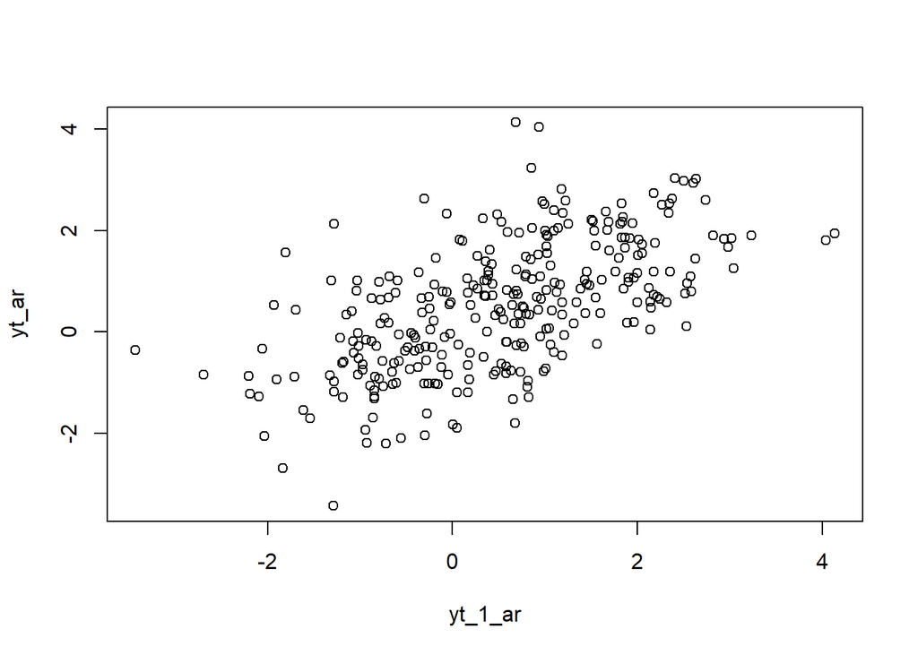

```r
plot(y=yt_ar,x=yt_1_ar)
```

Berdasarkan scatterplot tersebut, terlihat bahwa terdapat hubungan positif antara $Y_t$ dengan $Y_{t-1}$. Hal ini sesuai dengan teori yang ada

```r
cor(yt_ar,yt_1_ar)
```

```
## [1] 0.5926736
```

Korelasi antara $Y_t$ dengan $Y_{t-1}$ dari hasil simulasi mendekati perhitungan teoritis yaitu

$$\rho_1=\frac{\phi_1}{1-\phi_2}=\frac{0.5}{1-0.2}=0.626$$

#### Korelasi antara $Y_t$ dengan $Y_{t-2}$

```r
#Yt
yt_ar2 <- ar[-c(1,2)]
yt_ar2
```

```
##   [1]  1.165955987  0.938001648  4.040029883  1.814697744  2.125920865
##   [6]  0.863714547  2.048268102  1.545945122  1.694180277  1.601619567
##  [11]  0.371264692  0.004847193 -1.831910620 -2.693657731 -0.848960327
##  [16] -1.308949603  1.013994421  1.918290789  1.846186931  2.263708856
##  [21]  2.502983054  2.980469932  1.670192649  2.009644523  1.825961756
##  [26]  1.867757240  1.866634014  1.656435730  2.373983431  2.630476742
##  [31]  3.014418988  1.853562001  0.855327159  3.232502351  1.899226305
##  [36]  0.992684756  2.515564069  0.760964948  0.497271510  0.449843159
##  [41] -0.848775762 -1.147182073  0.345806314  0.712429910  0.358807807
##  [46]  1.386418838  0.848700937  1.431531414  1.028995087  1.889603063
##  [51]  0.178539914 -0.931313695 -0.157885545 -1.034479287  0.814903596
##  [56] -0.967592210 -0.646423203 -1.031097913  1.012508610  0.830899026
##  [61]  0.339712179 -0.487081048 -0.308557477  2.628643225  1.440297143
##  [66]  0.370609149  1.011299471 -0.719521142 -2.204256171 -0.875847780
##  [71] -0.182803871  1.454982068  0.951672894 -0.084193829 -0.105019556
```

[output cut: 45 more lines]

```r
#Yt-2
yt_2_ar <- ar[-c(299,300)]
yt_2_ar
```

```
##   [1]  1.000000000  2.000000000  1.165955987  0.938001648  4.040029883
##   [6]  1.814697744  2.125920865  0.863714547  2.048268102  1.545945122
##  [11]  1.694180277  1.601619567  0.371264692  0.004847193 -1.831910620
##  [16] -2.693657731 -0.848960327 -1.308949603  1.013994421  1.918290789
##  [21]  1.846186931  2.263708856  2.502983054  2.980469932  1.670192649
##  [26]  2.009644523  1.825961756  1.867757240  1.866634014  1.656435730
##  [31]  2.373983431  2.630476742  3.014418988  1.853562001  0.855327159
##  [36]  3.232502351  1.899226305  0.992684756  2.515564069  0.760964948
##  [41]  0.497271510  0.449843159 -0.848775762 -1.147182073  0.345806314
##  [46]  0.712429910  0.358807807  1.386418838  0.848700937  1.431531414
##  [51]  1.028995087  1.889603063  0.178539914 -0.931313695 -0.157885545
##  [56] -1.034479287  0.814903596 -0.967592210 -0.646423203 -1.031097913
##  [61]  1.012508610  0.830899026  0.339712179 -0.487081048 -0.308557477
##  [66]  2.628643225  1.440297143  0.370609149  1.011299471 -0.719521142
##  [71] -2.204256171 -0.875847780 -0.182803871  1.454982068  0.951672894
```

[output cut: 45 more lines]

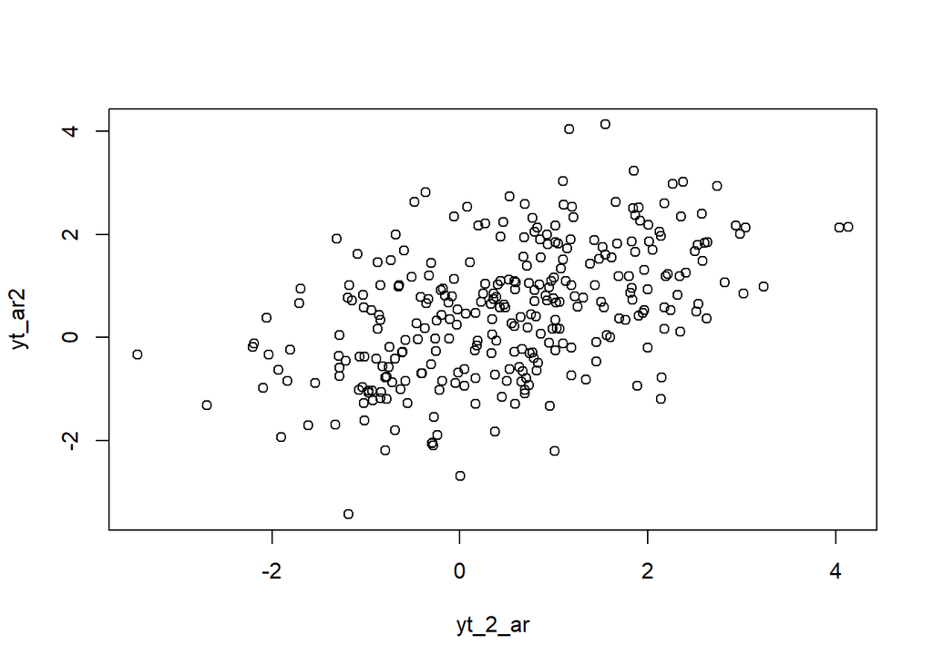

```r
plot(y=yt_ar2,x=yt_2_ar)
```

Berdasarkan scatterplot tersebut, terlihat bahwa terdapat hubungan positif antara $Y_t$ dengan $Y_{t-2}$. Hal ini sesuai dengan teori yang ada

```r
cor(yt_ar2,yt_2_ar)
```

```
## [1] 0.4820466
```

Korelasi antara $Y_t$ dengan $Y_{t-2}$ dari hasil simulasi mendekati perhitungan teoritis yaitu

$$\rho_1=\frac{\phi_1^2}{1-\phi_2}+\phi_2=\frac{0.5^2}{1-0.2}+0.2=0.5125$$

#### Korelasi antara $Y_t$ dengan $Y_{t-3}$

```r
#Yt
yt_ar3 <- ar[-c(1,2,3)]
yt_ar3
```

```
##   [1]  0.938001648  4.040029883  1.814697744  2.125920865  0.863714547
##   [6]  2.048268102  1.545945122  1.694180277  1.601619567  0.371264692
##  [11]  0.004847193 -1.831910620 -2.693657731 -0.848960327 -1.308949603
##  [16]  1.013994421  1.918290789  1.846186931  2.263708856  2.502983054
##  [21]  2.980469932  1.670192649  2.009644523  1.825961756  1.867757240
##  [26]  1.866634014  1.656435730  2.373983431  2.630476742  3.014418988
##  [31]  1.853562001  0.855327159  3.232502351  1.899226305  0.992684756
##  [36]  2.515564069  0.760964948  0.497271510  0.449843159 -0.848775762
##  [41] -1.147182073  0.345806314  0.712429910  0.358807807  1.386418838
##  [46]  0.848700937  1.431531414  1.028995087  1.889603063  0.178539914
##  [51] -0.931313695 -0.157885545 -1.034479287  0.814903596 -0.967592210
##  [56] -0.646423203 -1.031097913  1.012508610  0.830899026  0.339712179
##  [61] -0.487081048 -0.308557477  2.628643225  1.440297143  0.370609149
##  [66]  1.011299471 -0.719521142 -2.204256171 -0.875847780 -0.182803871
##  [71]  1.454982068  0.951672894 -0.084193829 -0.105019556  0.793754820
```

[output cut: 45 more lines]

```r
#Yt-3
yt_3_ar <- ar[-c(298,299,300)]
yt_3_ar
```

```
##   [1]  1.000000000  2.000000000  1.165955987  0.938001648  4.040029883
##   [6]  1.814697744  2.125920865  0.863714547  2.048268102  1.545945122
##  [11]  1.694180277  1.601619567  0.371264692  0.004847193 -1.831910620
##  [16] -2.693657731 -0.848960327 -1.308949603  1.013994421  1.918290789
##  [21]  1.846186931  2.263708856  2.502983054  2.980469932  1.670192649
##  [26]  2.009644523  1.825961756  1.867757240  1.866634014  1.656435730
##  [31]  2.373983431  2.630476742  3.014418988  1.853562001  0.855327159
##  [36]  3.232502351  1.899226305  0.992684756  2.515564069  0.760964948
##  [41]  0.497271510  0.449843159 -0.848775762 -1.147182073  0.345806314
##  [46]  0.712429910  0.358807807  1.386418838  0.848700937  1.431531414
##  [51]  1.028995087  1.889603063  0.178539914 -0.931313695 -0.157885545
##  [56] -1.034479287  0.814903596 -0.967592210 -0.646423203 -1.031097913
##  [61]  1.012508610  0.830899026  0.339712179 -0.487081048 -0.308557477
##  [66]  2.628643225  1.440297143  0.370609149  1.011299471 -0.719521142
##  [71] -2.204256171 -0.875847780 -0.182803871  1.454982068  0.951672894
```

[output cut: 45 more lines]

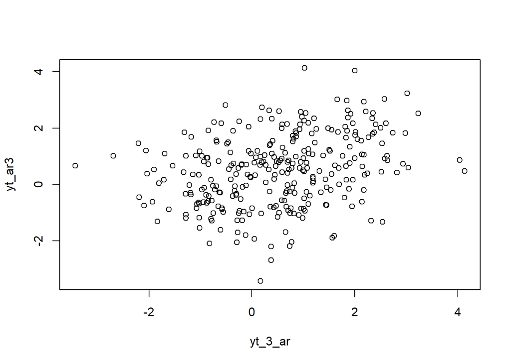

```r
plot(y=yt_ar3,x=yt_3_ar)
```

Berdasarkan scatterplot tersebut, terlihat bahwa terdapat hubungan positif antara $Y_t$ dengan $Y_{t-3}$. Hal ini sesuai dengan teori yang ada

```r
cor(yt_ar3,yt_3_ar)
```

```
## [1] 0.3101654
```

## Fungsi pembangkitan ARMA

Bentuk umum data berpola ARMA.

$$y_{t} = c + \sum_{i=1}^p \phi_{i}y_{t-i} + \sum_{j=1}^q e_{t-j}+ e_{t}$$

## Pembangkitan Proses ARMA(2,2)

```r
set.seed(035)
n = length(wn)
phi1 = 0.5
phi2 = 0.2

theta1 = 0.4
theta2 = 0.6

y.arma=c(1:n)
for (i in 5:n){y.arma[i] = phi1*y.arma[i-1] +phi2*y.arma[i-2] + theta1*wn[i-1] + phi2*y.arma[i-2]+wn[i]}
y.arma
```

```
##   [1]  1.00000000  2.00000000  3.00000000  4.00000000  6.51984732  5.80214128
##   [7]  5.76240857  4.80410177  5.67336680  5.58388293  5.71246954  5.73974999
##  [13]  4.56461783  3.76974738  1.60169004 -0.23336275  0.67677656  0.24500555
##  [19]  2.09317953  3.55298000  3.96723786  4.63546523  5.28930189  6.17583017
##  [25]  5.39349157  5.61727649  5.68451752  5.83685720  5.98093763  5.90180419
##  [31]  6.65554282  7.26966647  7.96631345  7.20103404  6.04080763  8.06520875
##  [37]  7.53448767  6.43466235  7.62913112  6.34882703  5.56160057  5.21481600
##  [43]  3.67850235  2.64315410  3.55702536  4.04039849  3.68402625  4.49607411
##  [49]  4.23118909  4.67741335  4.46663037  5.25047544  3.87534893  2.25053612
##  [55]  2.38806925  1.43380062  2.72813885  1.31492966  0.95585329  0.35928752
##  [61]  2.01358014  2.34430626  1.91169185  0.95915586  0.78204851  3.60184102
##  [67]  3.45356221  2.36732425  2.75291525  1.23926880 -0.84567207 -0.37564618
##  [73]  0.31795315  2.00866016  2.08087540  1.09717213  0.78726833  1.59430349
##  [79]  1.44110062  1.71577269  1.89541472  0.45870351 -0.20946941 -1.76007828
##  [85] -1.52949347 -0.51098529 -0.64238231 -0.36433595 -0.27752064  0.31243029
```

[output cut: 35 more lines]

```r
set.seed(1234)
n = length(wn)
phi1 = 0.7 #ARMA 1 1
theta1 = 0.5

y.arma=c(1:n)
for (i in 3:n){y.arma[i] = phi1*y.arma[i-1] + theta1*wn[i-1]+wn[i]}
y.arma
```

```
##   [1]  1.000000000  2.000000000  1.432396579  0.940679254  3.973825166
##   [6]  4.057679020  3.054482567  1.781235370  2.156998697  2.454580578
##  [11]  2.404294581  2.384123659  1.123175616 -0.099076708 -2.228495384
##  [16] -4.292912206 -3.030123812 -2.034699230  0.241102881  2.760986160
##  [21]  3.453474713  3.716510858  4.081927457  4.634531474  3.561651420
##  [26]  2.911290742  2.814231591  2.766360053  2.780438809  2.579655962
##  [31]  3.152981574  3.905504364  4.514335926  3.592484272  1.750529931
##  [36]  3.322328504  3.654602836  2.010747967  2.745185574  2.045964079
##  [41]  0.698174058  0.344574366 -0.907442380 -2.034548311 -0.741412727
##  [46]  0.794550511  0.874098530  1.643113718  1.766174036  2.008083981
##  [51]  1.914096569  2.500411431  1.322626984 -0.958695693 -1.098275798
##  [56] -1.402035174 -0.002341160 -0.487926789 -1.251230645 -1.553033229
##  [61]  0.313035012  1.578659916  1.092255036 -0.197657945 -0.682878421
##  [66]  2.335843584  3.262946621  1.502638080  1.152148090 -0.223821311
##  [71] -2.853076765 -2.650346948 -0.974179344  1.387613645  2.092848966
```

[output cut: 45 more lines]

Pembangkitan ARMA(p,q) juga dapat dilakukan dengan fungsi `arima.sim` sebagai berikut.

```r
arma22 <- arima.sim(list(order=c(2,0,2), ar = c(0.5,0.2), ma =c(0.4,0.6)), n=300)
arma22
```

```
## Time Series:
## Start = 1
## End = 300
## Frequency = 1
##   [1] -2.75189059 -1.74814288 -2.98064692 -1.12111691 -1.75293106 -1.33898765
##   [7] -2.09046996 -3.56829323 -4.32225209 -6.49932813 -7.02769509 -6.95242810
##  [13] -6.26996407 -3.43890672 -3.74182891 -2.97181976 -3.49823015 -3.96328709
##  [19] -4.21591372 -4.99194225 -5.61517562 -5.49498965 -5.32810268 -6.08211738
##  [25] -5.70927763 -6.49640104 -6.19781946 -5.63181804 -4.16631811 -1.43386858
##  [31] -1.32659085  1.33518960 -0.57718012  1.13545868  2.56923465  2.89049818
##  [37]  2.80495292  1.68426168  2.77538382  1.29220743  3.17981524  3.04188012
##  [43]  3.84589813  3.47054592  2.25362466  1.27634579  1.31729358  3.02358708
##  [49]  2.83893413  1.81428668  0.10302896 -0.45121970 -0.85290753 -0.66635425
##  [55] -0.93510416 -2.14779642 -2.08562341 -1.51503473 -0.24121274  0.91556687
##  [61]  0.64537308  0.48311177 -1.14217407 -1.12039092 -1.27141453  0.91636167
```

[output cut: 39 more lines]

## Karakteristik ARMA(2,2)

### Plot Time Series

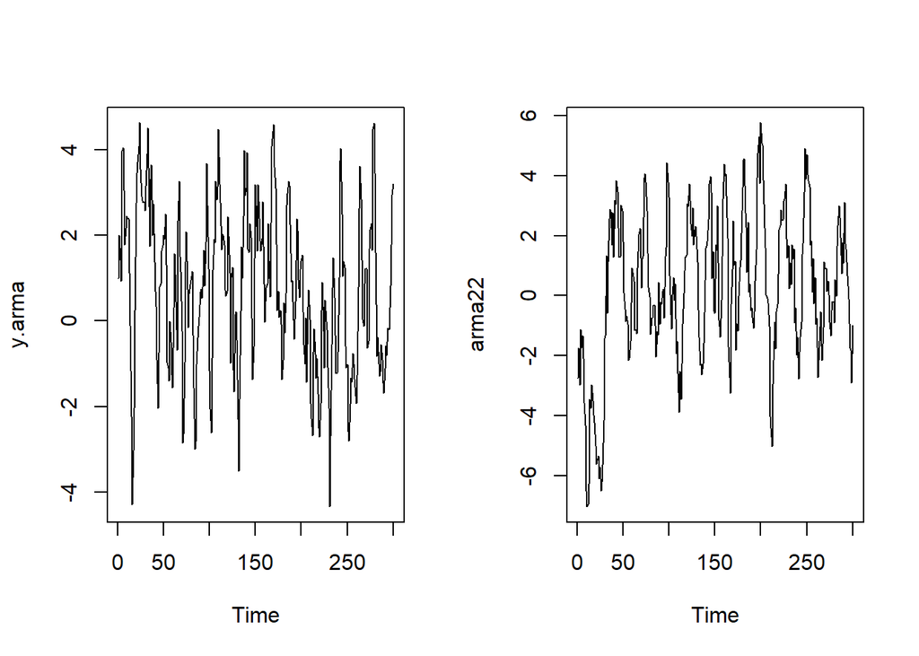

```r
par(mfrow = c(1, 2))
ts.plot(y.arma)
ts.plot(arma22)
```

```r
par(mfrow = c(1, 1))
```

Berdasarkan plot time series tersebut, terlihat bahwa model ARMA(2,2) cenderung stasioner dalam rataan

### Plot ACF

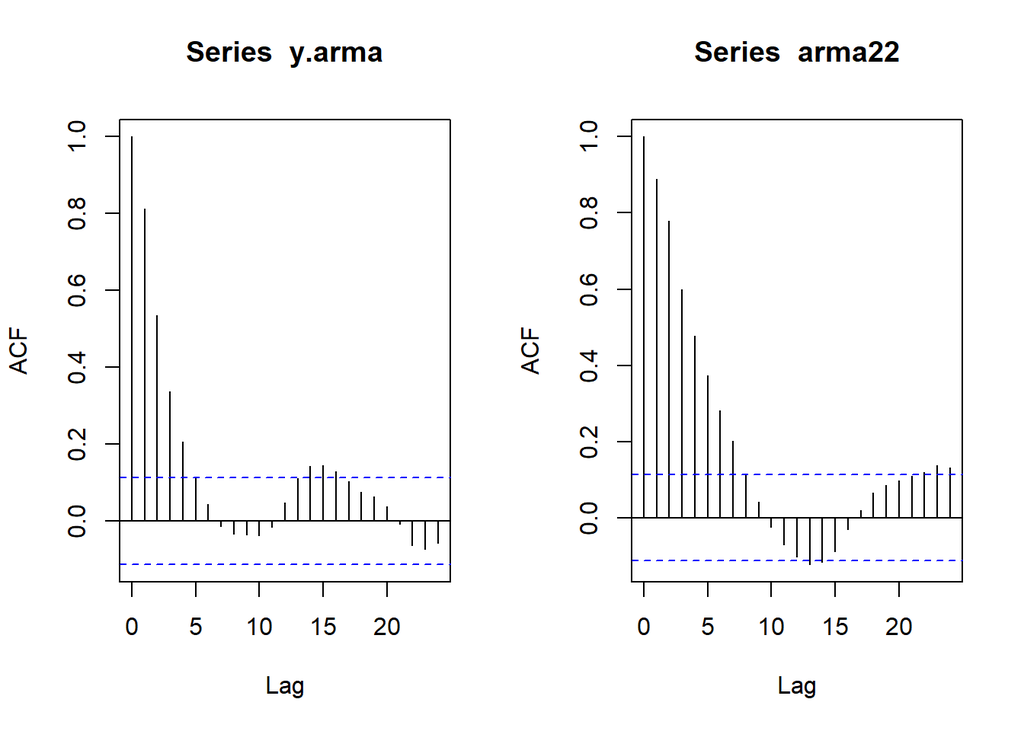

```r
par(mfrow = c(1, 2))
acf(y.arma)
acf(arma22)
```

```r
par(mfrow = c(1, 1))
```

Berdasarkan plot ACF tersebut, terlihat bahwa model ARMA(2,2) hasil simulasi memiliki plot ACF yang *tails off*, sesuai dengan teori yang ada

### Plot PACF

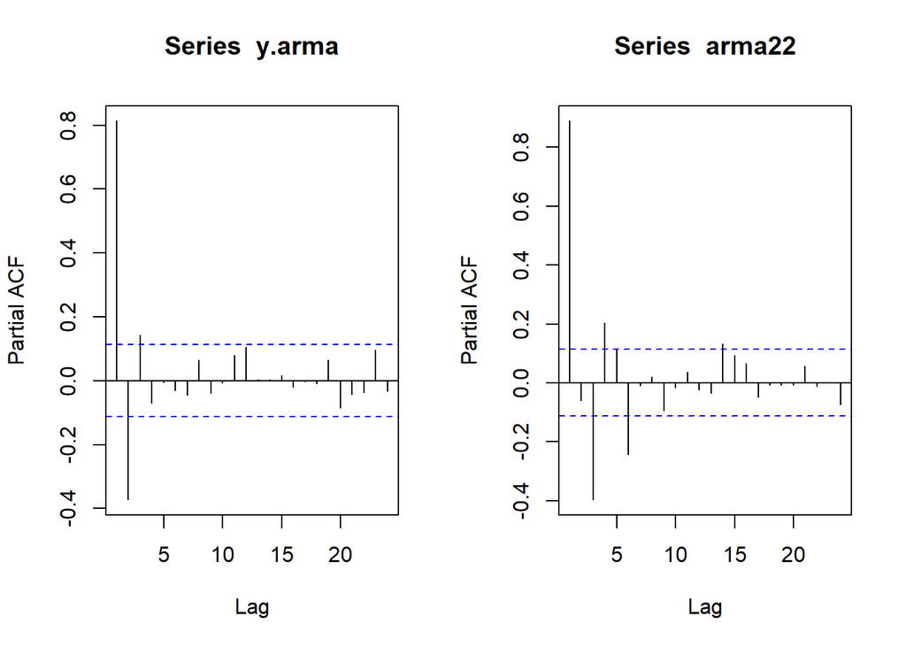

```r
par(mfrow = c(1, 2))
pacf(y.arma)
pacf(arma22)
```

```r
par(mfrow = c(1, 1))
```

Berdasarkan plot PACF tersebut, terlihat bahwa model ARMA(2,2) hasil simulasi memiliki plot PACF yang *tails off*, sesuai dengan teori

### Plot EACF

```r
TSA::eacf(y.arma)
```

```
## AR/MA
##   0 1 2 3 4 5 6 7 8 9 10 11 12 13
## 0 x x x x o o o o o o o  o  o  x
## 1 x o o o o o o o o o o  o  o  o
## 2 x x o o o o o o o o o  o  o  o
## 3 x x x o o o o o o o o  o  o  o
## 4 x x x o o o o o o o o  o  o  o
## 5 x o o o x o o o o o o  o  o  o
## 6 x o x x o x o o o o o  o  o  o
## 7 x x o x o x o o o o o  o  o  o
```

```r
TSA::eacf(arma22)
```

```
## AR/MA
##   0 1 2 3 4 5 6 7 8 9 10 11 12 13
## 0 x x x x x x x o o o o  o  x  o
## 1 o x o o o o x o o o o  o  o  o
## 2 x x o o o o o o o o o  o  o  o
## 3 x x x x o o o o o o o  o  o  o
## 4 x x x x o o o o o o o  o  o  o
## 5 x x x x x x x o o o o  o  o  o
## 6 o o x o x x o o o o o  o  o  o
## 7 x o x x x x o x o o o  o  o  o
```

Berdasarkan pola segitiga nol pada plot EACF, terlihat bahwa segitiga nol berada pada ordo AR(2) dan ordo MA(2)

### Scatterplot Antar Lag

#### Korelasi antara $Y_t$ dengan $Y_{t-1}$

```r
#Yt
yt_arma <- arma22[-1]
yt_arma
```

```
##   [1] -1.74814288 -2.98064692 -1.12111691 -1.75293106 -1.33898765 -2.09046996
##   [7] -3.56829323 -4.32225209 -6.49932813 -7.02769509 -6.95242810 -6.26996407
##  [13] -3.43890672 -3.74182891 -2.97181976 -3.49823015 -3.96328709 -4.21591372
##  [19] -4.99194225 -5.61517562 -5.49498965 -5.32810268 -6.08211738 -5.70927763
##  [25] -6.49640104 -6.19781946 -5.63181804 -4.16631811 -1.43386858 -1.32659085
##  [31]  1.33518960 -0.57718012  1.13545868  2.56923465  2.89049818  2.80495292
##  [37]  1.68426168  2.77538382  1.29220743  3.17981524  3.04188012  3.84589813
##  [43]  3.47054592  2.25362466  1.27634579  1.31729358  3.02358708  2.83893413
##  [49]  1.81428668  0.10302896 -0.45121970 -0.85290753 -0.66635425 -0.93510416
##  [55] -2.14779642 -2.08562341 -1.51503473 -0.24121274  0.91556687  0.64537308
##  [61]  0.48311177 -1.14217407 -1.12039092 -1.27141453  0.91636167  2.04091439
##  [67]  2.13232979  2.23257264  0.25301429  1.21071226  1.29939237  3.92904462
##  [73]  4.07112121  3.78513073  2.83160983  1.41191959  0.28488816 -0.04006883
##  [79] -1.28812485 -0.74220308 -0.74424287 -0.32976863 -0.31752860 -0.98342470
##  [85] -2.04217397 -1.20184647 -1.31314616  0.45270778 -0.93468943 -0.20680752
```

[output cut: 35 more lines]

```r
#Yt-1
yt_1_arma <- arma22[-300]
yt_1_arma
```

```
##   [1] -2.75189059 -1.74814288 -2.98064692 -1.12111691 -1.75293106 -1.33898765
##   [7] -2.09046996 -3.56829323 -4.32225209 -6.49932813 -7.02769509 -6.95242810
##  [13] -6.26996407 -3.43890672 -3.74182891 -2.97181976 -3.49823015 -3.96328709
##  [19] -4.21591372 -4.99194225 -5.61517562 -5.49498965 -5.32810268 -6.08211738
##  [25] -5.70927763 -6.49640104 -6.19781946 -5.63181804 -4.16631811 -1.43386858
##  [31] -1.32659085  1.33518960 -0.57718012  1.13545868  2.56923465  2.89049818
##  [37]  2.80495292  1.68426168  2.77538382  1.29220743  3.17981524  3.04188012
##  [43]  3.84589813  3.47054592  2.25362466  1.27634579  1.31729358  3.02358708
##  [49]  2.83893413  1.81428668  0.10302896 -0.45121970 -0.85290753 -0.66635425
##  [55] -0.93510416 -2.14779642 -2.08562341 -1.51503473 -0.24121274  0.91556687
##  [61]  0.64537308  0.48311177 -1.14217407 -1.12039092 -1.27141453  0.91636167
##  [67]  2.04091439  2.13232979  2.23257264  0.25301429  1.21071226  1.29939237
##  [73]  3.92904462  4.07112121  3.78513073  2.83160983  1.41191959  0.28488816
##  [79] -0.04006883 -1.28812485 -0.74220308 -0.74424287 -0.32976863 -0.31752860
##  [85] -0.98342470 -2.04217397 -1.20184647 -1.31314616  0.45270778 -0.93468943
```

[output cut: 35 more lines]

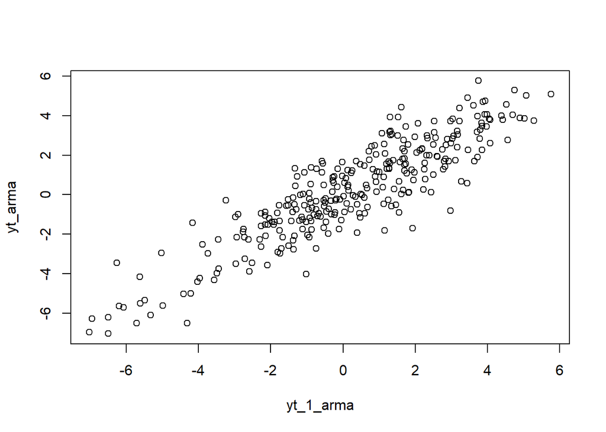

```r
plot(y=yt_arma,x=yt_1_arma)
```

Berdasarkan scatterplot tersebut, terlihat bahwa terdapat hubungan positif antara $Y_t$ dengan $Y_{t-1}$. Hal ini sesuai dengan teori yang ada

```r
cor(yt_arma,yt_1_arma)
```

```
## [1] 0.8918177
```

#### Korelasi antara $Y_t$ dengan $Y_{t-2}$

```r
#Yt
yt_arma2 <- arma22[-c(1,2)]
yt_arma2
```

```
##   [1] -2.98064692 -1.12111691 -1.75293106 -1.33898765 -2.09046996 -3.56829323
##   [7] -4.32225209 -6.49932813 -7.02769509 -6.95242810 -6.26996407 -3.43890672
##  [13] -3.74182891 -2.97181976 -3.49823015 -3.96328709 -4.21591372 -4.99194225
##  [19] -5.61517562 -5.49498965 -5.32810268 -6.08211738 -5.70927763 -6.49640104
##  [25] -6.19781946 -5.63181804 -4.16631811 -1.43386858 -1.32659085  1.33518960
##  [31] -0.57718012  1.13545868  2.56923465  2.89049818  2.80495292  1.68426168
##  [37]  2.77538382  1.29220743  3.17981524  3.04188012  3.84589813  3.47054592
##  [43]  2.25362466  1.27634579  1.31729358  3.02358708  2.83893413  1.81428668
##  [49]  0.10302896 -0.45121970 -0.85290753 -0.66635425 -0.93510416 -2.14779642
##  [55] -2.08562341 -1.51503473 -0.24121274  0.91556687  0.64537308  0.48311177
##  [61] -1.14217407 -1.12039092 -1.27141453  0.91636167  2.04091439  2.13232979
##  [67]  2.23257264  0.25301429  1.21071226  1.29939237  3.92904462  4.07112121
##  [73]  3.78513073  2.83160983  1.41191959  0.28488816 -0.04006883 -1.28812485
##  [79] -0.74220308 -0.74424287 -0.32976863 -0.31752860 -0.98342470 -2.04217397
##  [85] -1.20184647 -1.31314616  0.45270778 -0.93468943 -0.20680752 -0.29613748
```

[output cut: 35 more lines]

```r
#Yt-2
yt_2_arma <- arma22[-c(299,300)]
yt_2_arma
```

```
##   [1] -2.75189059 -1.74814288 -2.98064692 -1.12111691 -1.75293106 -1.33898765
##   [7] -2.09046996 -3.56829323 -4.32225209 -6.49932813 -7.02769509 -6.95242810
##  [13] -6.26996407 -3.43890672 -3.74182891 -2.97181976 -3.49823015 -3.96328709
##  [19] -4.21591372 -4.99194225 -5.61517562 -5.49498965 -5.32810268 -6.08211738
##  [25] -5.70927763 -6.49640104 -6.19781946 -5.63181804 -4.16631811 -1.43386858
##  [31] -1.32659085  1.33518960 -0.57718012  1.13545868  2.56923465  2.89049818
##  [37]  2.80495292  1.68426168  2.77538382  1.29220743  3.17981524  3.04188012
##  [43]  3.84589813  3.47054592  2.25362466  1.27634579  1.31729358  3.02358708
##  [49]  2.83893413  1.81428668  0.10302896 -0.45121970 -0.85290753 -0.66635425
##  [55] -0.93510416 -2.14779642 -2.08562341 -1.51503473 -0.24121274  0.91556687
##  [61]  0.64537308  0.48311177 -1.14217407 -1.12039092 -1.27141453  0.91636167
##  [67]  2.04091439  2.13232979  2.23257264  0.25301429  1.21071226  1.29939237
##  [73]  3.92904462  4.07112121  3.78513073  2.83160983  1.41191959  0.28488816
##  [79] -0.04006883 -1.28812485 -0.74220308 -0.74424287 -0.32976863 -0.31752860
##  [85] -0.98342470 -2.04217397 -1.20184647 -1.31314616  0.45270778 -0.93468943
```

[output cut: 35 more lines]

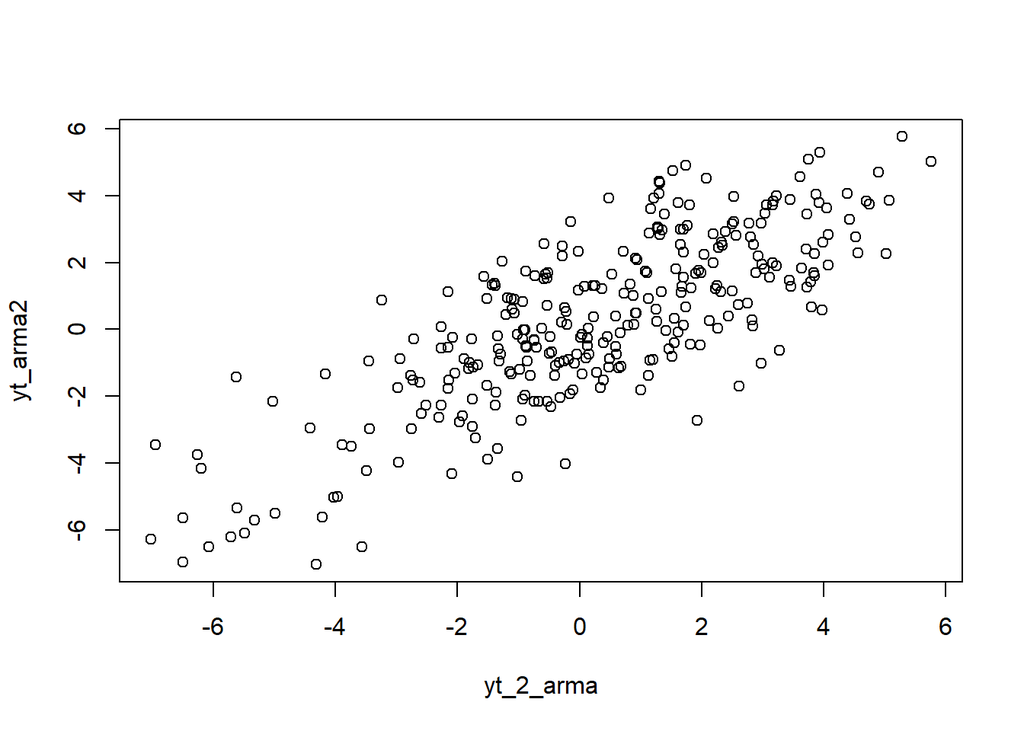

```r
plot(y=yt_arma2,x=yt_2_arma)
```

Berdasarkan scatterplot tersebut, terlihat bahwa terdapat hubungan positif antara $Y_t$ dengan $Y_{t-2}$. Hal ini sesuai dengan teori yang ada

```r
cor(yt_arma2,yt_2_arma)
```

```
## [1] 0.7836583
```

#### Korelasi antara $Y_t$ dengan $Y_{t-3}$

```r
#Yt
yt_arma3 <- arma22[-c(1,2,3)]
yt_arma3
```

```
##   [1] -1.12111691 -1.75293106 -1.33898765 -2.09046996 -3.56829323 -4.32225209
##   [7] -6.49932813 -7.02769509 -6.95242810 -6.26996407 -3.43890672 -3.74182891
##  [13] -2.97181976 -3.49823015 -3.96328709 -4.21591372 -4.99194225 -5.61517562
##  [19] -5.49498965 -5.32810268 -6.08211738 -5.70927763 -6.49640104 -6.19781946
##  [25] -5.63181804 -4.16631811 -1.43386858 -1.32659085  1.33518960 -0.57718012
##  [31]  1.13545868  2.56923465  2.89049818  2.80495292  1.68426168  2.77538382
##  [37]  1.29220743  3.17981524  3.04188012  3.84589813  3.47054592  2.25362466
##  [43]  1.27634579  1.31729358  3.02358708  2.83893413  1.81428668  0.10302896
##  [49] -0.45121970 -0.85290753 -0.66635425 -0.93510416 -2.14779642 -2.08562341
##  [55] -1.51503473 -0.24121274  0.91556687  0.64537308  0.48311177 -1.14217407
##  [61] -1.12039092 -1.27141453  0.91636167  2.04091439  2.13232979  2.23257264
##  [67]  0.25301429  1.21071226  1.29939237  3.92904462  4.07112121  3.78513073
##  [73]  2.83160983  1.41191959  0.28488816 -0.04006883 -1.28812485 -0.74220308
##  [79] -0.74424287 -0.32976863 -0.31752860 -0.98342470 -2.04217397 -1.20184647
##  [85] -1.31314616  0.45270778 -0.93468943 -0.20680752 -0.29613748  0.15497575
```

[output cut: 35 more lines]

```r
#Yt-3
yt_3_arma <- arma22[-c(298,299,300)]
yt_3_arma
```

```
##   [1] -2.75189059 -1.74814288 -2.98064692 -1.12111691 -1.75293106 -1.33898765
##   [7] -2.09046996 -3.56829323 -4.32225209 -6.49932813 -7.02769509 -6.95242810
##  [13] -6.26996407 -3.43890672 -3.74182891 -2.97181976 -3.49823015 -3.96328709
##  [19] -4.21591372 -4.99194225 -5.61517562 -5.49498965 -5.32810268 -6.08211738
##  [25] -5.70927763 -6.49640104 -6.19781946 -5.63181804 -4.16631811 -1.43386858
##  [31] -1.32659085  1.33518960 -0.57718012  1.13545868  2.56923465  2.89049818
##  [37]  2.80495292  1.68426168  2.77538382  1.29220743  3.17981524  3.04188012
##  [43]  3.84589813  3.47054592  2.25362466  1.27634579  1.31729358  3.02358708
##  [49]  2.83893413  1.81428668  0.10302896 -0.45121970 -0.85290753 -0.66635425
##  [55] -0.93510416 -2.14779642 -2.08562341 -1.51503473 -0.24121274  0.91556687
##  [61]  0.64537308  0.48311177 -1.14217407 -1.12039092 -1.27141453  0.91636167
##  [67]  2.04091439  2.13232979  2.23257264  0.25301429  1.21071226  1.29939237
##  [73]  3.92904462  4.07112121  3.78513073  2.83160983  1.41191959  0.28488816
##  [79] -0.04006883 -1.28812485 -0.74220308 -0.74424287 -0.32976863 -0.31752860
##  [85] -0.98342470 -2.04217397 -1.20184647 -1.31314616  0.45270778 -0.93468943
```

[output cut: 35 more lines]

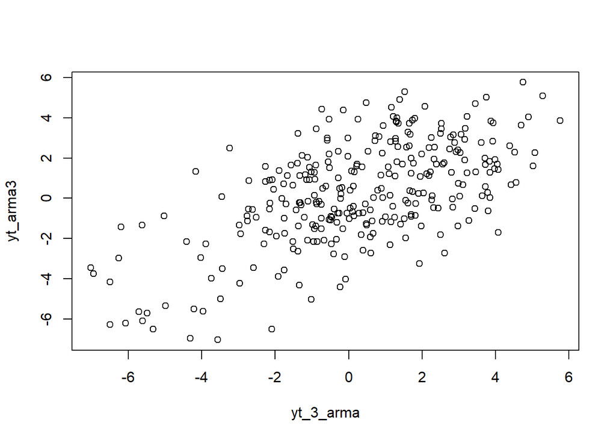

```r
plot(y=yt_arma3,x=yt_3_arma)
```

Berdasarkan scatterplot tersebut, terlihat bahwa terdapat hubungan positif antara $Y_t$ dengan $Y_{t-3}$. Hal ini sesuai dengan teori yang ada

```r
cor(yt_arma3,yt_3_arma)
```

```
## [1] 0.6044325
```